# act_report_david

## We Rate Dogs Act Report

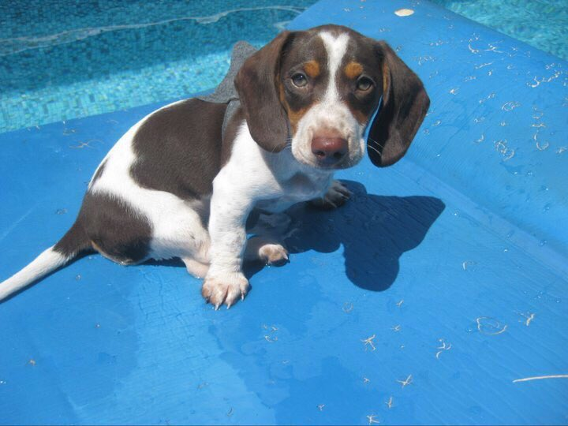

## Introduction

The project gathers data from different sources related to the WeRateDogs twitter account, which posts and rates photos of folowers' dogs.This data was raw. As such, it needed cleaning and various transformations prior to analysis.

After assessing and cleaning the data, analysis is carried out and reports are written to communicate the results of an initial analysis.

The analysis proccess lead in giving insoghts on:

> 1. What are the Top Ten most rated dog breeds
> 2. What are the Ten Least Rated dog breeds.
> 3. What dog breed has the most retweet count.
> 4. What Dod Breed is the most favorite and what do stage does it belong

### Insight 1

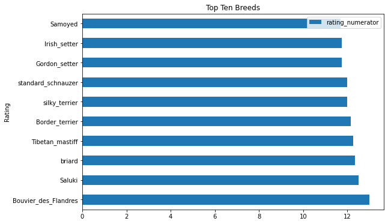

### Insight 2

Although the general distribution of the rating by breed is highly skewed to the right, indicating very high ratings of dogs.The least rated dog breed was the Japanese Spaniel with a meager rating of 5.

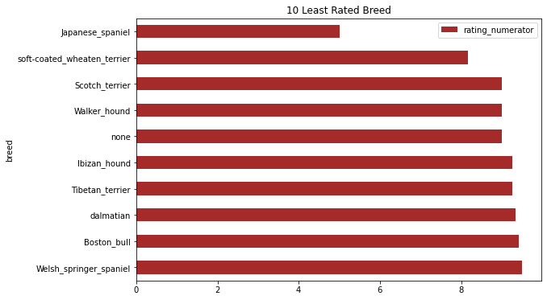

### Insight 3

When looking at the retweeted count, the dog breed that comes on top is the labrador Retriever. That boasts a whooping retweeted count of 79,515.

### Insight 4

From the rating distribution, it is clear that dogs are loved. However, when looking at the favoites of many, the Lakeland terrier in the the doggo stage is held closest to the hearts of many dog lovers. The Lakeland Terrier tops as the most favorited dog breed with about 132,810 favorite count hits.